# Mitral Valve Replacement Data Simulation

Gaurika Tyagi

7 May 2016

# Mitral Valve Replacement (50 to 69 year olds)- Bioprosthetic vs Mechanical

## Introduction

Mitral valve disease is a conditions of the mitral valve. This is located between the left chambers of the heart and works to keep blood flowing properly. It allows blood to pass from the left atrium to the left ventricle but prevents it from flowing backwards. People with Mitral disease have a disfunctional mitral valve which allows the flow of blood backwards to the atrium. This disease may lead to heart failure or irregular heartbeats, which may be life threatening.

Many people do not experience any symptom. However, in cases where there are symptoms, they are:

1. Fatigue
2. Shortness of breath

This study focuses on the **survival outcomes following bioproshetic v/s mechanical Mitral Valve replacement**. It is only based on patients aged between 50-69 years as it is a challenging task to decide between the two because the long-term survival and morbidity are not well defined.

19 baseline characteristics yielded 664 patient pairs.

**Definitions** *Morbidity*: Morbidity is used to describe how often a disease occurs in a specific area or to describe a focus on death. In other words, it is the incidence of disease.

*Propensity Score*: In the statistical analysis propensity score matching (PSM) is a statistical matching technique that attempts to estimate the effect of a treatment by accounting for the covariates that predict receiving the treatment.

*Comorbidity*: The simultaneous presence of two chronic diseases or conditions in a patient

## Objective

The aim of the study is to quantify the survival and morbidity after valve replacement in patients aged 50-69 years.

## Study Results

1. *Survival Difference*: None at 15 years of observation
2. *Stroke and Bleeding*: Higher in those who received mechanical prosthetic mitral valves compared
3. *Reoperation*: Lower in the mechanical prosthesis group compared with the bioprosthesis group

## Data Introduction

This data simulation study aims to explore the survival outcome in people who have undergone a Mitral Valve replacement. Specifically, people who had bioprosthetic valve replacement viz-a-viz a mechanical valve replacement. Presence of various comorbidities along with this replacement are also kept in the picture. These are: coagulation, hypertension, diabetes mellitus, sepsis, coronary artery disease, congestive heart failure, atrial fibrillation, peripheral vascular disease, cerebro vascular disease, chronic obstructive pulmonary disease, chronic kidney disease, liver disease and cancer.

Initially, 2 datasets will be simulated:

1. People who underwent bioprosthetics valve replacement: dataset dimensions (795 rows, 20 columns)
2. People who underwent mechanical prosthetics valve replacement: dataset dimensions (2638 rows, 20 columns)

Finally, these will be paired and the data set will be reduced to 664 rows in each of the above mentioned datasets. Wemwill then add a column for whether these people are dead or alive (the research paper only talks about mortality once the matched pairing has been taken care of).

Important points about the predictor variables:

*Age is normally distributed.

*All other variables are Bernoulli distributions based on their probability of occurrence.

*Group is defined based on if they belong to the bio-prosthetics group or the mechanical prosthetics group.

*There is no missing data in this simulation.

*The response variable is simulated later as a variable in the matched data frames as a Boolean variable with 0 for no death and 1 for death. It will be simulated based on the comorbidities recorded.

*The response variable death has the following positively correlated factors: cancer, congestive heart failure, age>60 and if the person was brought in in an emergency.

*Confounders are not being added while data simulation but we will explore their presence when performing correlation analysis

Pairing of the preliminary data-sets will be done on the baisis of demographics and comorbidities. We will utilize the paired datasets and fit models to understand the effect of one variable on another. We will also merge the two data sets and try and understand how the analysis would differ if the datasets were not paired. Plots will also be generated to depict correlation and the various distributions.

We will utilize the paired datasets and fit models to understand the effect of one variable on another. We will also merge the two data sets and try and understand how the analysis would differ if the datasets were not paired. Plots will also be generated to depict correlation and the various distributions.

## Data Simulation

Install Libraries

```r
#install.packages("ggplot2")
#install.packages("survival")
#install.packages("matchingR")
#install.packages("kimisc")
#install.packages("useful")
#install.packages("rpart")
library(rpart)
library(rpart.plot)
library(useful)
library(matchingR)
library(ggplot2)
library(survival)
library(kimisc)
library(reshape2)
```

### Generate dataset for people who underwent Bioprosthetic Mitral Valve Replacement

```r
set.seed(0)
genBioProsthetic <- function(number){

  #Demographics
  age <- rnorm(n = number, mean = 61.2, sd = 5.9)
  #density distribution of age
  hist(age, main = "Density of age distribution for Bioprosthetics",
       freq = FALSE, ylim = c(0, 0.08) , xlab = "Age in years")
  lines(density(age), col = "dark green", lty="dotted")

  #we know that 43% of the Bioprosthetics are males
  male <- rep(x = "male", times = floor(0.43*number))
  female <- rep(x = "female", times = ceiling(0.57*number))
  sex_raw <- c(male, female)
  sex <- sample(x = sex_raw, size = number, replace = FALSE)
  #distribution of age by sex
  boxplot(age~sex,  col = (c("pink","blue")),
        main = "Distribution of Age by Sex", xlab = "Sex", ylab = "Age(in years)")

  non_his_w <- rep(x = "Non_Hispanic_White", times = floor(0.57*number))
  non_his_b <- rep(x = "Non_Hispanic_Black", times = floor(0.13*number))
  hisp <- rep(x = "Hispanic", times = ceiling(0.08*number))
  oth <- rep(x = "Other", times = ceiling(0.22*number))
  race_raw <- c(non_his_w, non_his_b, hisp, oth)
  race <- sample(x = race_raw, size = number, replace = FALSE)
  #distribution of age by race
  boxplot(age~race,  col = (c("Dark Green","blue", "Yellow", "Red")),
        main = "Distribution of Age by Race", xlab = "Race", ylab = "Age(in years)",
        cex.axis=0.75)

  emergent_admission <- rbinom(n = number, size = 1, prob = 0.55)

  concomitant_tricuspid_valve_repair <- rbinom(n = number, size = 1, prob = 0.05)

  #Comorbidities
  coagulation <- rbinom(n = number, size = 1, prob = 0.07)
  hypertension <- rbinom(n = number, size = 1, prob = 0.59)
  diabetes_mellitus <- rbinom(n = number, size = 1, prob = 0.25)
  sepsis <- rbinom(n = number, size = 1, prob = 0.04)
  coronory_artery_disease_raw <- c(rep(x = "Without_Prior_Revascularization",
                                       times = ceiling(0.32*number)),
                                 rep(x = "Prior_PCI", times = floor(0.04*number)),
                                 rep(x = "Prior_CABG_Surgery", times = ceiling(0.06*number)),
                                 rep(x = "None", times = ceiling(0.58*number))
                                )
  coronary_artery_disease <- sample(x = coronory_artery_disease_raw, size = number, replace = FALSE)
  congestive_heart_failure <- rbinom(n = number, size = 1, prob = 0.58)
  atrial_fibrillation <- rbinom(n = number, size = 1, prob = 0.43)
  peripheral_vascular_disease <- rbinom(n = number, size = 1, prob = 0.05)
  cerebro_vascular_disease <- rbinom(n = number, size = 1, prob = 0.09)
  chronic_obstructive_pulmonary_disease <- rbinom(n = number, size = 1, prob = 0.23)
  chronic_kidney_disease <- rbinom(n = number, size = 1, prob = 0.11)
  liver_disease <- rbinom(n = number, size = 1, prob = 0.08)
  cancer <- rbinom(n = number, size = 1, prob = 0.05)

  #Year of Surgery
  years_raw <- c(rep(x = "1997", times = floor(0.03*number)),
               rep(x = "1998", times = floor(0.04*number)),
               rep(x = "1999", times = floor(0.05*number)),
               rep(x = "2000", times = floor(0.05*number)),
               rep(x = "2001", times = floor(0.08*number)),
               rep(x = "2002", times = ceiling(0.08*number)),
               rep(x = "2003", times = ceiling(0.09*number)),
               rep(x = "2004", times = ceiling(0.13*number)),
               rep(x = "2005", times = ceiling(0.13*number)),
               rep(x = "2006", times = ceiling(0.15*number)),
               rep(x = "2007", times = ceiling(0.17*number))
               )
  year <- sample(x = years_raw, size = number, replace = FALSE)

  group <- rep(x = "bio", size = number, replace = FALSE)

  #collaborate all features to develop data set
  bioprosthetics <- data.frame(age, sex, race, emergent_admission,
                               concomitant_tricuspid_valve_repair, coagulation, hypertension,
                               diabetes_mellitus, sepsis, coronary_artery_disease,
                               congestive_heart_failure, atrial_fibrillation,
                               peripheral_vascular_disease, cerebro_vascular_disease,
                               chronic_obstructive_pulmonary_disease, chronic_kidney_disease,
                               liver_disease, cancer, year, group)

  return(bioprosthetics)
}
print("Generating dataset for people who had Bioprosthetic Valve replacement")
```

```
## [1] "Generating dataset for people who had Bioprosthetic Valve replacement"
```

```r
bioprosthetic_group <- genBioProsthetic(795)
```

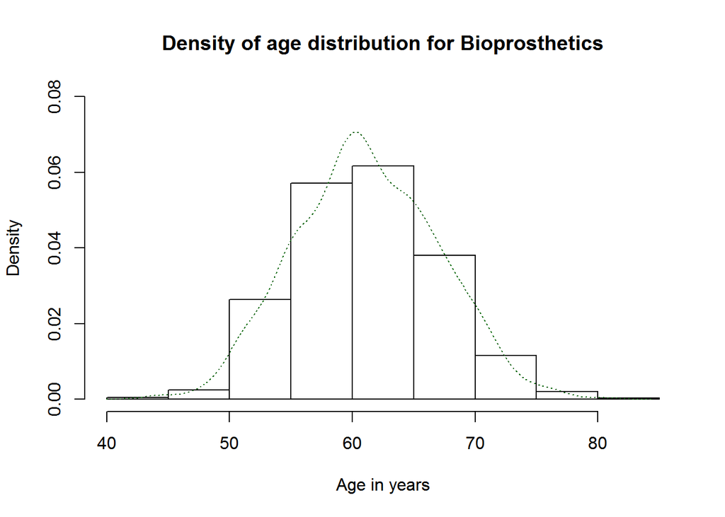

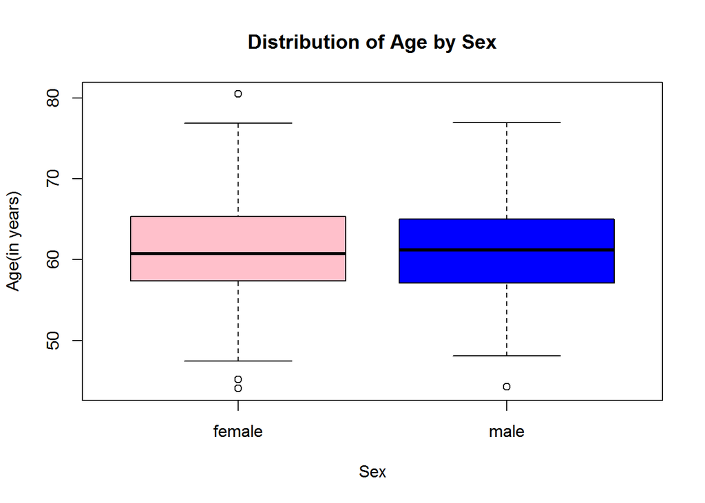

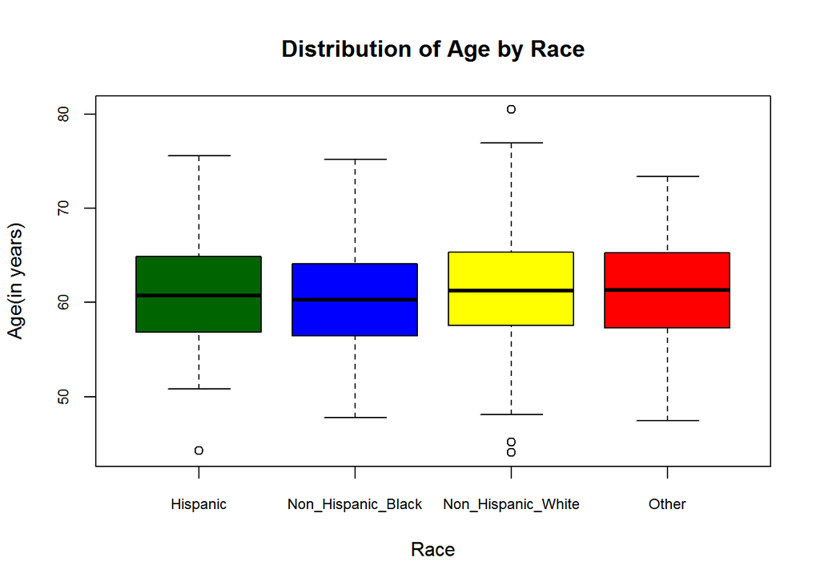

Similary now we need to develop the data set for group of people who underwent Mechanical Prosthetic Mitral Valve replacement.

### Generate dataset for people who underwent Mechanical Prosthetic Mitral Valve Replacement

```r
genMechanicalProsthetic <- function(number){

  #Demographics
  age <- rnorm(n = number, mean = 59.7, sd = 5.7)
  #density distribution of age
  hist(age, main = "Density of age distribution for Bioprosthetics",
       freq = FALSE, ylim = c(0, 0.08) , xlab = "Age in years")
  lines(density(age), col = "dark green", lty="dotted")

  #we know that 40% of the Mechanical Prosthetics are males
  male <- rep(x = "male", times = floor(0.40*number))
  female <- rep(x = "female", times = ceiling(0.60*number))
  sex_raw <- c(male, female)
  sex <- sample(x = sex_raw, size = number, replace = FALSE)
  #distribution of age by sex
  boxplot(age~sex,  col = (c("pink","blue")),
        main = "Distribution of Age by Sex", xlab = "Sex", ylab = "Age(in years)")

  non_his_w <- rep(x = "Non_Hispanic_White", times = floor(0.56*number))
  non_his_b <- rep(x = "Non_Hispanic_Black", times = floor(0.11*number))
  hisp <- rep(x = "Hispanic", times = ceiling(0.07*number))
  oth <- rep(x = "Other", times = ceiling(0.26*number))
  race_raw <- c(non_his_w, non_his_b, hisp, oth)
  race <- sample(x = race_raw, size = number, replace = FALSE)
  #distribution of age by race
  boxplot(age~race,  col = (c("Dark Green","blue", "Yellow", "Red")),
        main = "Distribution of Age by Race", xlab = "Race", ylab = "Age(in years)",
        cex.axis=0.75)

  emergent_admission <- rbinom(n = number, size = 1, prob = 0.42)

  concomitant_tricuspid_valve_repair <- rbinom(n = number, size = 1, prob = 0.03)

  #Comorbidities
  coagulation <- rbinom(n = number, size = 1, prob = 0.05)
  hypertension <- rbinom(n = number, size = 1, prob = 0.52)
  diabetes_mellitus <- rbinom(n = number, size = 1, prob = 0.17)
  sepsis <- rbinom(n = number, size = 1, prob = 0.02)
  coronory_artery_disease_raw <- c(rep(x = "Without_Prior_Revascularization",
                                       times = ceiling(0.25*number)),
                                   rep(x = "Prior_PCI", times = floor(0.02*number)),
                                   rep(x = "Prior_CABG_Surgery", times = ceiling(0.04*number)),
                                   rep(x = "None", times = ceiling(0.69*number))
                                  )
  coronary_artery_disease <- sample(x = coronory_artery_disease_raw, size = number, replace = FALSE)

  congestive_heart_failure <- rbinom(n = number, size = 1, prob = 0.53)
  atrial_fibrillation <- rbinom(n = number, size = 1, prob = 0.51)
  peripheral_vascular_disease <- rbinom(n = number, size = 1, prob = 0.03)
  cerebro_vascular_disease <- rbinom(n = number, size = 1, prob = 0.08)
  chronic_obstructive_pulmonary_disease <- rbinom(n = number, size = 1, prob = 0.18)
  chronic_kidney_disease <- rbinom(n = number, size = 1, prob = 0.06)
  liver_disease <- rbinom(n = number, size = 1, prob = 0.04)
  cancer <- rbinom(n = number, size = 1, prob = 0.02)

  #Year of Surgery
  years_raw <- c(rep(x = "1997", times = floor(0.12*number)),
               rep(x = "1998", times = floor(0.12*number)),
               rep(x = "1999", times = floor(0.10*number)),
               rep(x = "2000", times = floor(0.11*number)),
               rep(x = "2001", times = floor(0.10*number)),
               rep(x = "2002", times = ceiling(0.09*number)),
               rep(x = "2003", times = ceiling(0.09*number)),
               rep(x = "2004", times = ceiling(0.08*number)),
               rep(x = "2005", times = ceiling(0.07*number)),
               rep(x = "2006", times = ceiling(0.06*number)),
               rep(x = "2007", times = ceiling(0.06*number))
               )
  year <- sample(x = years_raw, size = number, replace = FALSE)
  group <- rep(x = "mechanical", size = number, replace = FALSE)

  #collaborate all features to develop data set
  mechprosthetics <- data.frame(age, sex, race, emergent_admission,
                               concomitant_tricuspid_valve_repair, coagulation, hypertension,
                               diabetes_mellitus, sepsis, coronary_artery_disease,
                               congestive_heart_failure, atrial_fibrillation,
                               peripheral_vascular_disease, cerebro_vascular_disease,
                               chronic_obstructive_pulmonary_disease, chronic_kidney_disease,
                               liver_disease, cancer, year, group)

  return(mechprosthetics)
}
print("Generating dataset for people who had Mechanical Prosthetic Valve replacement")
```

```
## [1] "Generating dataset for people who had Mechanical Prosthetic Valve replacement"
```

```r
mechprosthetic_group <- genMechanicalProsthetic(2638)
```

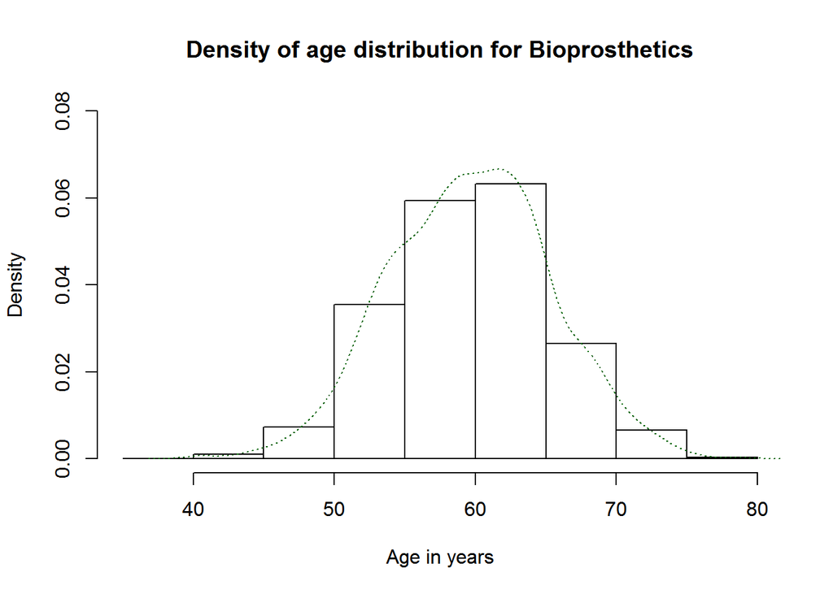

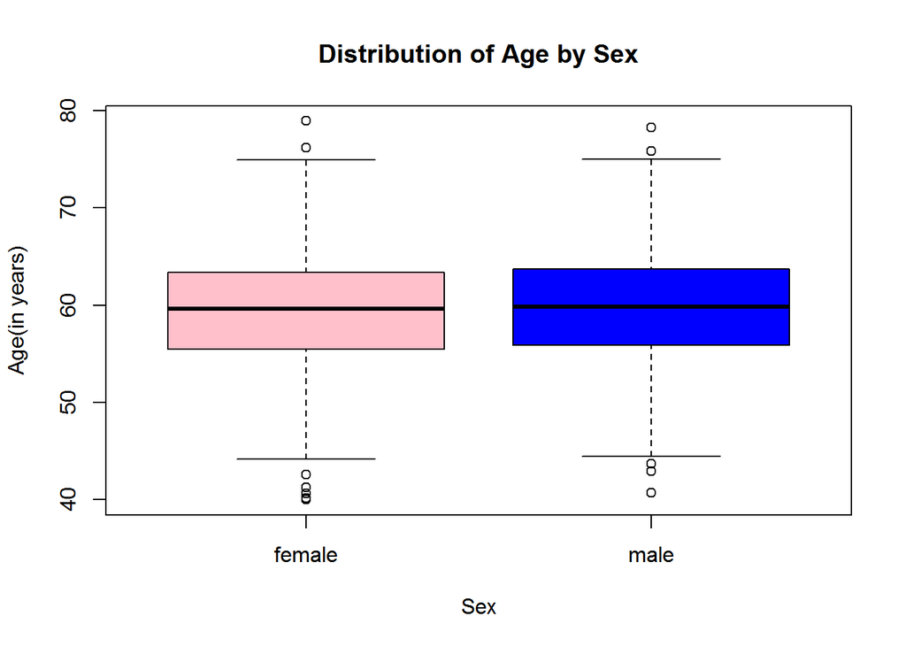

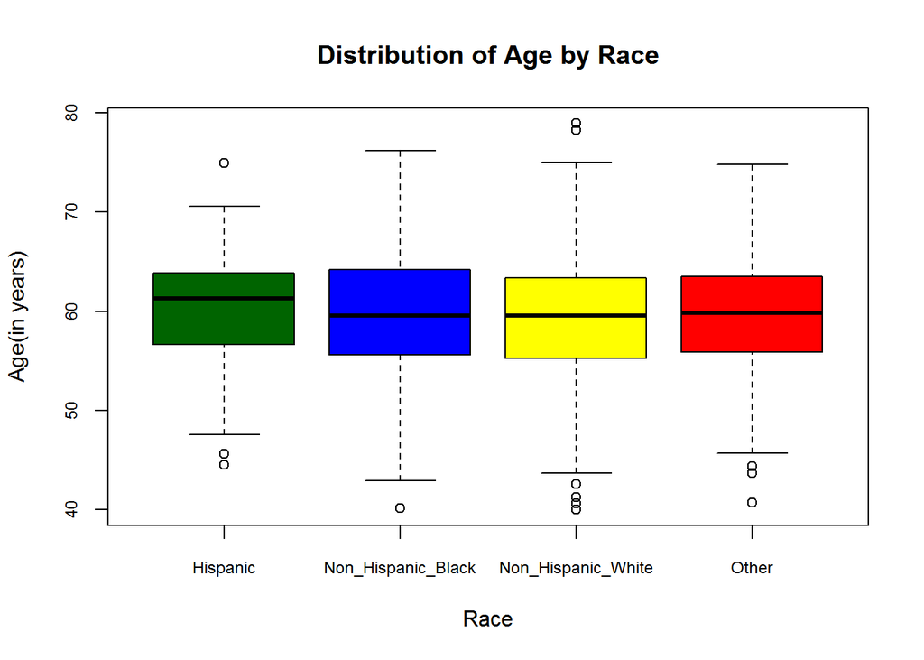